# AICE1006 - Data Analytics

## Lecture 1 - Introduction

**Zhiwu Huang**  
Lecturer (Assistant Professor)  
Vision, Learning and Control (VLC) Research Group  
School of Electronics and Computer Science (ECS)  
University of Southampton

*Office Hour: Wed 2PM-3PM, Please book in advance.*  
`Zhiwu.Huang@soton.ac.uk`

Credit: Marco Forgione, Researcher, USI-SUPSI

# Overview

Objective:

- To get acquainted with the most common data manipulation (exploratory data analysis, EDA) techniques
- To develop an intuitive understanding of real-world datasets
- To improve your programming skills with focus on data science applications

Main Topics:

- Data ingestion (how to load data)
- Data wrangling (concatenate, join, pivot,...)
- Data visualization (scatter plots, histograms, box plots,...)
- Basic data analysis (mean, standard deviation, correlation,...)
- Advanced data analysis (principal component analysis, manifold learning, clustering,...)
- More advanced (advanced machine/deep learning,...): NOT INCLUDED IN AICE1006

You may see similar concepts in the other modules like AICE1008: Mathematics.  
The focus of the Data Analytics module is on applications rather than theory!

## Data Visualization Examples

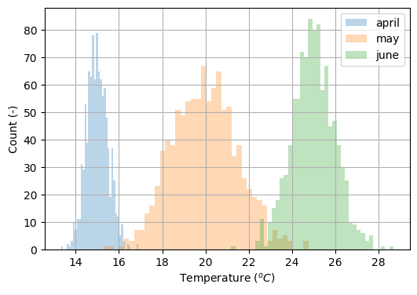

```python
import matplotlib.pyplot as plt;
import numpy as np
temp_april = np.random.normal(15, 0.5, 1000) # mean, std, n_sample
temp_may = np.random.normal(20, 1.5, 1000);
temp_june = np.random.normal(25, 1, 1000)

kwargs = dict(histtype='stepfilled', alpha=0.3,  bins=40)
plt.figure(figsize=(6, 4));
plt.hist(temp_april, **kwargs, label='april')
plt.hist(temp_may, **kwargs, label='may');
plt.hist(temp_june, **kwargs, label='june')
plt.xlabel('Temperature $(^oC)$', fontsize=10); plt.ylabel('Count (-)', fontsize=10);
plt.grid(); plt.legend(fontsize=10);
```

## Data Visualization Examples

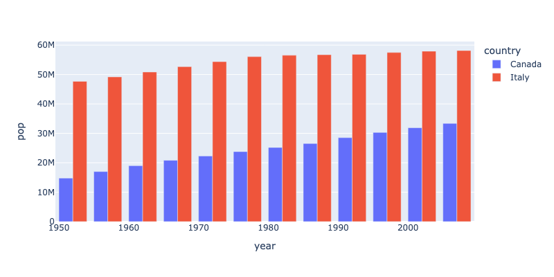

```python
### Scatter plot
import plotly.express as px;
from IPython.display import Image
data_canada_it = px.data.gapminder().query("country == 'Canada' or country == 'Italy'")
fig = px.bar(data_canada_it, x='year', y='pop', color="country", barmode="group", width= 800, height=400)
# fig.show();
fig.write_image('figure.png');Image(filename='figure.png')
```

## Data Visualization Examples

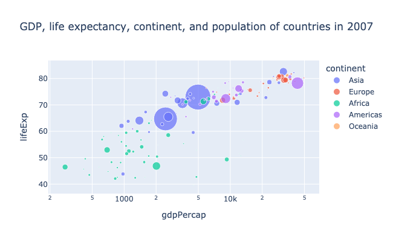

```python
import plotly.express as px;
from IPython.display import Image
df = px.data.gapminder()
# A richer scatterplot
fig = px.scatter(df.query("year==2007"), x="gdpPercap", y="lifeExp", size="pop", color="continent", hover_name="country", log_x=True,
           title="GDP, life expectancy, continent, and population of countries in 2007", size_max=30, width=650, height=400)
# fig.show();
fig.write_image('figure.png');Image(filename='figure.png')
```

# Software tools

- Python (programming language)
- Jupyter Notebook (web-based programming interface)
- Python libraries:
  - Numpy (numerical mathematics)
  - **Pandas** (tabular data handling)
  - Matplotlib, Pandas, and Seaborn (data visualization)
  - ...

## Resources

Required:

- The course's slides
- Official documentation of [python](https://www.python.org/doc/), [pandas](https://pandas.pydata.org/docs/), [matplotlib](https://matplotlib.org/stable/contents.html), ...
- Google, stack overflow, ChatGPT ...

Optional:

- The book "Python for Data Analysis" by Wes McKinney ([link](https://wesmckinney.com/book/) on the Wes's blog)
- The book "Hands-On Exploratory Data Analysis with Python" by Wes McKinney ([link](https://download.packt.com/free-ebook/9781789537253), the link to claim your free PDF)
- The book "Python Data Science" by Jake Vanderplas (available [on-line](https://github.com/jakevdp/PythonDataScienceHandbook) for free)

# Getting started

- Install all the required packages. Type in a terminal:

```
$ pip install numpy scipy pandas scikit-learn matplotlib jupyter
$ pip install rise
$ pip install plotly
$ pip install --upgrade notebook==6.4.12 traitlets==5.9.0 jupyter jupyter_contrib_nbextensions (recommended)
```

- Start Jupyter notebook/lab. Type in a terminal:

```
$ jupyter notebook

or

$ jupyter lab
```

```
A page should appear in your default browser. Otherwise, copy-paste the link from your terminal in the browser.

On Windows, Chrome seems to work better.
```

- Start Jupyter notebook in VS Code (Recommended):

https://code.visualstudio.com/docs/datascience/jupyter-notebooks

# Introduction to Jupyter notebook

A web-based Python environment very good for:

- Rapid prototyping
- Small/medium data science projects
- Presenting results (these slides made with Jupyter!)

Jupyter allows mixing **formatted text** and python code. The cell below contains Python code!

```python
print("Welcome to the data analytics module!")
#a = 1
#b = a + 1
#print(b)
```

```
Welcome to the data analytics module!
```

Don't use Jupyter for a large software development project! Go for an IDE like PyCharm or VSCode instead.

[figure not shown]

## Cell

The cell is the basic input unit in a Jupyter notebook. Common operations:

- Add a cell
  - Select an existing cell by clicking in the white area at its left
  - Click on Insert -> Insert Cell Above/Below (or click a/b)
- Remove a cell
  - Select a cell
  - Click on Edit -> Delete Cells (or click x)
- Move a cell
  - Select the cell (hold shift to select multiple cells)
  - Use the arrows to move the cell up and down

#### Cell type

- A cell may contain either Python code or Markdown (= formatted text).
- This slide is made up of Markdown cells!
- To change the cell type, select Python or Markdown in the drop-down menu

# Python for data science

Python is an *interpreted*, *dynamically typed* programming language.

- No need to compile the code. A virtual machine interprets it on the fly.
- No need to declare variable types. They are inferred at run-time (dynamic typing).

```python
# Sum numbers from 0 to 9
result = 0
for i in range(10):
    result += i
print(result) # result = 0 + 1 + 2 + .. + 9 = 45
```

```
45
```

```python
result = "foo" # now the type of the variable result changes dynamically to str
```

Conversely, C is a compiled, statically typed language.

```
// file main.c
// C language: sum numbers from 0 to 9
int result=0; // need to declare result as an integer variable
for(int i=0; i<10; i++){
    result += i;
}
printf("%d", result);
//result = 'foo' // this would result in a compile error!
```

In C, we need to first compile main.c, and then execute the generated program.

# Python for data science

- Python is user-friendly, but it can be slower than a compiled language when used without care
- To get full speed, specialized libraries for the most intensive tasks must be used

In this course, we use Python for data science in conjunction with packages such as:

- [numpy](https://numpy.org/) for number crunching
- [pandas](https://pandas.pydata.org/) for handling tabular data
- [matplotlib](https://matplotlib.org/) and [plotly](https://plotly.com/) for data visualization
- [scikit-learn](https://scikit-learn.org/) for machine learning
- ...

Using these packages, we can tackle different data science tasks in Python without compromising performance.

But first, let us review some Python basics!

# Data types

Python is a *dynamically typed* language. No need to define variable type. It is inferred at run-time.

```python
counter = 1 # an integer
val = 3.14 # a float (floating point number)
message = "Hello, world" # a string. Also message = 'Hello, world' works
flag = False # a Boolean variable. Possible values: {True, False}
#val_c = 0.5 + 0.4j # a complex number (real + imaginary part)

type(message)
```

```
str
```

The variable type can change at run-time:

```python
message = 42 # message is now an int!
type(message)
```

```
int
```

The variable message was first a string, then it was changed to int. This is OK for Python.

# Basic operations

Basic arithmetic operations `+`, `-`, `/`, `*` behave as expected on numeric types:

```python
val1 = 3.14
val2 = 42
val3 = val1 + val2
val3
```

```
45.14
```

```python
type(val1), type(val2), type(val3)
```

```
(float, int, float)
```

```python
val2/val1
```

```
13.375796178343949
```

Basic operations `+` and `*` are also defined on strings:

```python
message1 = "Hello, "
message2 = "World"
message = message1  + message2 # string "sum"
message
```

```
'Hello, World'
```

```python
message1 * 3 # string "multiplication"
```

```
'Hello, Hello, Hello, '
```

# Data structures

## Lists

A **list** is an ordered collection of python objects:

```python
object_lst = [3.14, "pear", 42] # a float, a string, an integer
object_lst
```

```
[3.14, 'pear', 42]
```

You can access its elements with square bracket notation and integer indexes 0,1,2...,`len(object_lst)-1`

```python
object_lst[2] # note: starting index is 0!
```

```
42
```

You can modify the elements of a list:

```python
object_lst[2] = 44
object_lst
```

```
[3.14, 'pear', 44]
```

You can append to a list using the append method:

```python
object_lst.append(-5)
object_lst
```

```
[3.14, 'pear', 44, -5]
```

# Data structures

## Lists

You can access more elements at once and get a sub-list:

```python
object_lst
```

```
[3.14, 'pear', 44, -5]
```

```python
object_lst[1:3] # returns the elements from index 1 to 3-1
```

```
['pear', 44]
```

The ''sum'' of two lists is the concatenation of its elements

```python
list1 = ["A", "B", "C"]
list2 = ["D", "E", "F"]
list1 + list2
```

```
['A', 'B', 'C', 'D', 'E', 'F']
```

The ''multiplication'' of a list times an integer is also defined:

```python
list1 * 3
```

```
['A', 'B', 'C', 'A', 'B', 'C', 'A', 'B', 'C']
```

# Data structures

## Tuples

A **tuple** is pretty much like a list, but it is immutable:

```python
object_tup = ("A", "B", False)
object_tup
```

```
('A', 'B', False)
```

```python
object_tup[0]
```

```
'A'
```

```python
# Don't do this!
#object_tup[0] = True
```

# Data structures

## Dictionaries

A **dictionary** is a collection of key-value pairs:

```python
# a dictionary is a collection of key-value pairs
fruit_cost_dict = {"apple": 1.0, "pear": 1.5, "strawberry": 2.0} # fruit cost (CHF)
fruit_cost_dict
```

```
{'apple': 1.0, 'pear': 1.5, 'strawberry': 2.0}
```

"apple", "pear", "strawberry" are the keys, 1.0, 1.5, 2.0 are the values

You can access its elements using *square bracket* notation:

```python
fruit_cost_dict["strawberry"] # dictionary[key] returns the corresponding value
```

```
2.0
```

You can modify the value associated to a key:

```python
fruit_cost_dict["strawberry"] = 2.5
```

You can even add a new key-value pair:

```python
fruit_cost_dict["mango"] = 5.0
```

# Control Flow

## If statement

Basic usage of the **if** statement: check a condition. If `True`, execute the code in the following block

```python
x = 1
if x > 0:
    print("x is greater than 0")
```

```
x is greater than 0
```

The optional **else** block, it is executed when the condition is `False`:

```python
x = 0
if x > 0:
    print("x is greater than 0")
else:
    print("x is smaller than (or equal to) 0")
```

```
x is smaller than (or equal to) 0
```

multiple **elif** blocks may be used to handle multiple cases:

```python
x = 0
if x == 0:
    print("x is equal 0")
elif x > 0:
    print("x is greater than 0")
else:
    print("x is smaller than 0")
```

```
x is equal 0
```

# Control Flow

## While loop

A **while** loop executes a block of code until a certain condition becomes `False` or a **break** statement is encountered:

```python
result = 0
idx = 0
while idx < 5:
    result = result + idx # or result += idx
    idx = idx + 1
result # = 0 + 1 + 2 + 3 + 4 = 10
```

```
10
```

```python
result = 0
idx = 0
while idx < 5:

    result = result + idx
    idx = idx + 1

    if result > 4:
        break

result # = 0 + 1 + 2 + 3 + 4 = 10
```

```
6
```

# Control Flow

## For loop

A **for** loop iterates over a sequence (a collection like a list or a tuple, or an iterator).

```python
name_lst = ["Marco", "Alice", "Dario", "Anna"]

for name in name_lst:
    print(name)
```

```
Marco
Alice
Dario
Anna
```

The **for** loop is generally more readable than the **while** equivalent:

```python
idx = 0
while(idx < len(name_lst)):
    print(name_lst[idx])
    idx = idx + 1
```

```
Marco
Alice
Dario
Anna
```

## The range iterator

It is very common to iterate over a numerical range. The `range` iterator comes in handy:

```python
# Print the square of the numbers from 0 to 4
for idx in range(5): # no need to declare a list [0, 1, 2, 3, 4]
    print(idx, idx**2) # print idx, idx squared
```

```
0 0
1 1
2 4
3 9
4 16
```

The code above is way more practical than explicitly constructing the sequence of values 0, 1, 2, 3, 4

In Python, `range(5)` is an **iterator** that behaves like the list [0, 1, 2, 3, 4]. It is more convenient to use the range iterator instead of explicitly constructing the equivalent list.

```python
list(range(5)) # now the range is explicitly converted to an equivalent list
```

```
[0, 1, 2, 3, 4]
```

We can also specify a starting index:

```python
list(range(1, 11)) # values from 1 to 10
```

```
[1, 2, 3, 4, 5, 6, 7, 8, 9, 10]
```

# Control Flow

## List comprehension

A very common task: **filter** the elements of a sequence according to a **logic condition**.

Example: take all the strings starting with A from a list

```python
name_lst = ["Marco", "Alice", "Dario", "Anna"]
```

```python
names_A = [] # result list
for name in name_lst:
    if name.startswith("A"):
        names_A.append(name)
names_A
```

```
['Alice', 'Anna']
```

**List comprehension** offers a shorthand alternative:

```python
names_A = [name for name in name_lst if name.startswith("A")]
names_A
```

```
['Alice', 'Anna']
```

# Control Flow

## List comprehension cont'd

Sometimes we want to **filter and transform** the elements of the sequence.

Example: take the **square** of all the **odd numbers** from 1 to 10

```python
squared_odds = [] # result_list
for num in range(1, 11):
    if num %2 == 1: # if the remainder of the division by 2 is zero...
        squared_odds.append(num**2)
squared_odds
```

```
[1, 9, 25, 49, 81]
```

This can also be done with list comprehension:

```python
squared_odds = [el**2 for el in range(1, 11) if el%2 == 1]
squared_odds
```

```
[1, 9, 25, 49, 81]
```

The general notation of **List comprehension** is thus: `[expr for el in iterable if condition]`.

# Modules

## The math module

In python, a **module** is just a .py python file (or a folder with more .py files). To use a module, you must first `import` it!

Example: the `math` module, with is part of the Python Standard Library.

```python
import math # import the math module
```

```python
math.pi, math.sin(math.pi/2), math.cos(math.pi/2), math.exp(0), math.log(1)
```

```
(3.141592653589793, 1.0, 6.123233995736766e-17, 1.0, 0.0)
```

Sometimes we want to import specific objects from a module:

```python
from math import pi, sin, cos, exp, log
```

```python
sin(pi/2), cos(pi/2), exp(0), log(1)
```

```
(1.0, 6.123233995736766e-17, 1.0, 0.0)
```

# Modules

## The os module

Another useful module is `os`. It exposes functionalities from the operative system.

```python
import os
```

```python
os.listdir() # list of files in a folder (with no arguments, the working folder)
```

```
['.DS_Store',
 '01_exercises.ipynb',
 '01_slides_jupyter.pptx',
 '01_slides_jupyter.pdf',
 'img',
 '01_slides_jupyter.ipynb',
 '01_exercises_solution.ipynb',
 '.ipynb_checkpoints',
 '01_slides_jupyter.slides.html',
 'slides_images',
 'example_notebook.ipynb',
 '01_configure.ipynb',
 'figure.png']
```

Example: find all the jupyter notebooks (.ipynbs) in a folder:

```python
# find all the jupyter notebooks (.ipynb) in the current folder
ipynb_lst = []
for file in os.listdir():
    if file.endswith(".ipynb"):
        ipynb_lst.append(file)
ipynb_lst
```

```
['01_exercises.ipynb',
 '01_slides_jupyter.ipynb',
 '01_exercises_solution.ipynb',
 'example_notebook.ipynb',
 '01_configure.ipynb']
```

```python
ipynb_lst = [file for file in os.listdir() if file.endswith(".ipynb")] # list of all .ipynb files
```

# Today's challenge

- Set up jupyter with all the required packages (Slide 11, getting started)
  - `pip install` all the required packages
  - Start jupyter
- Familiarize with Jupyter notebook:
  - Access jupyter from your favorite web browser or VS code (recommended)
  - Create a new notebook
  - Create/remove/reorder/execute cells
  - Change cells type from code to markdown
  - Save notebook with name
- Familiarize with Python types and basic control flow
  - Strings, integers, floats
  - List, dictionaries
  - For loop, if statement